# Shape Variables and Shape Spaces

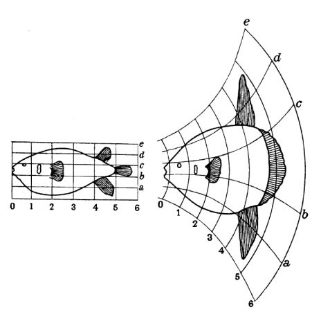

Antigoni Kaliontzopoulou, Universitat de Barcelona

01 June, 2026

# From GPA to Shape Data

- In this lecture we:
  - Obtain variables we can use for analyses
  - Review the relative position of individuals in shape space
  - Visualize shape variation

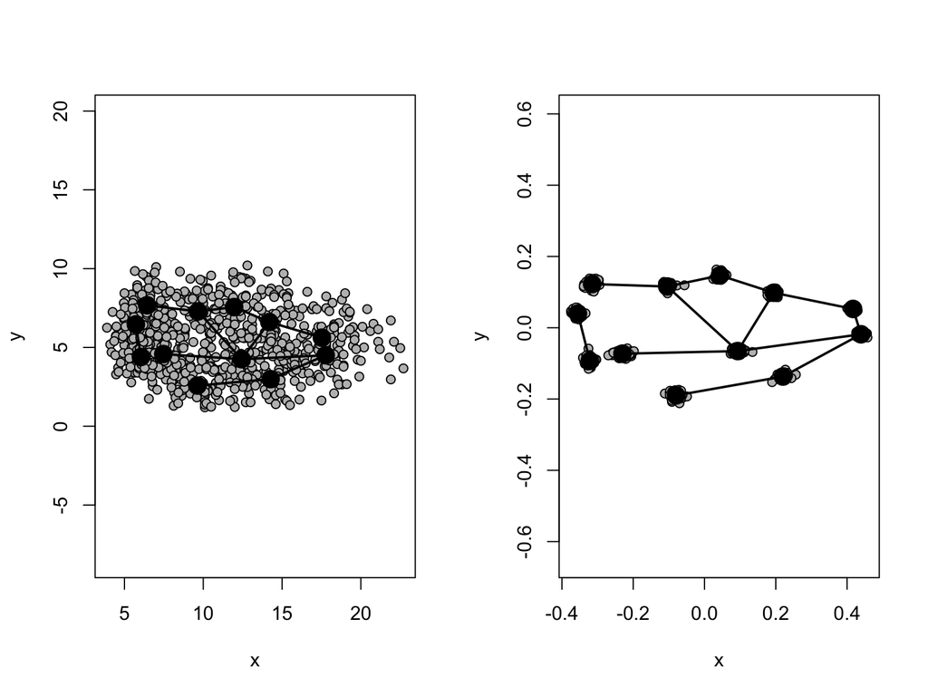

# Shape Spaces from GPA

- After GPA, each landmark configuration is a point in shape space
- The ‘center’ of this universe is the consensus (global mean shape)
- Each shape occupies a unique point in shape space
- The metric of shape space is the Procrustes distance $\small{D}_{Proc}$

$$\tiny{D}_{Proc}=\sqrt{\sum_{i,j}^{k,p}\left(\mathbf{Y}_{1.ij}-\mathbf{Y}_{2.ij}\right)^2}$$

- **Shape space is curved!**

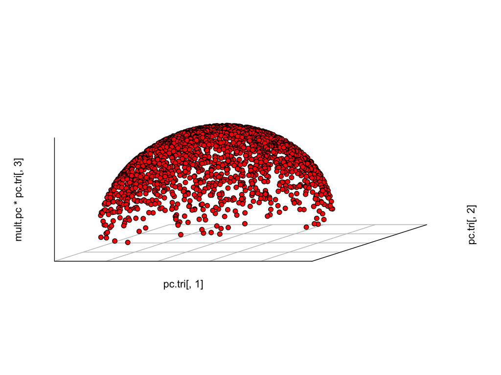

  Example with 2,000 random (uniform) triangles.  
  Note overabundance of shapes near ‘north pole’.

# Consequences of GPA

- With GPA, specimen location, scale and rotation are standardized, resulting in redundant dimensions
- $\small{2p-4}$ for 2D landmarks or $\small{3p-7}$ for 3D landmarks
- Statistical Challenges:
  - Covariance matrices are singular, so statistical hypothesis testing via parametric approaches cannot be completed
  - Shape space is curved, and most standard statistics assume linear spaces
- Solutions:
  - Data projection to a tangent space. This provides both a linear approximation to shape space and allows for redudant dimensions to be removed
  - Use RRPP (residual randomization in permutation procedures) for evaluating statistical hypotheses (subsequent lectures)

# Kendall’s Tangent Space Coordinates

- Orthogonal projection of shapes to linear tangent space

$$\small\mathbf{X}'=\mathbf{X\left(I_{kp}-X_c^T(X_cX_c^T)^{-1}X_c\right)}$$

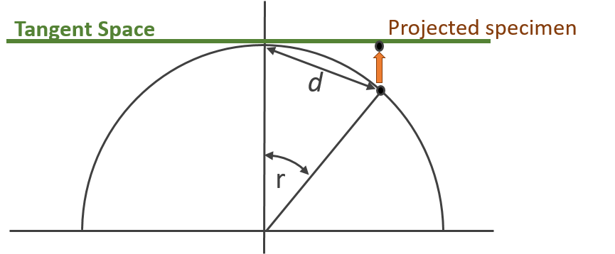

- Specimen scores from projection are Kendall’s tangent space coordinates (Dryden and Mardia, 1993; Kent 1994)
- Perform PCA and retain only 2p-4 (3D: 3p-7) shape variables with variation if desired (**NOTE: permutation via RRPP is now standard practice, so this step is not strictly necessary!**)

# Kendall’s Tangent Space Coordinates

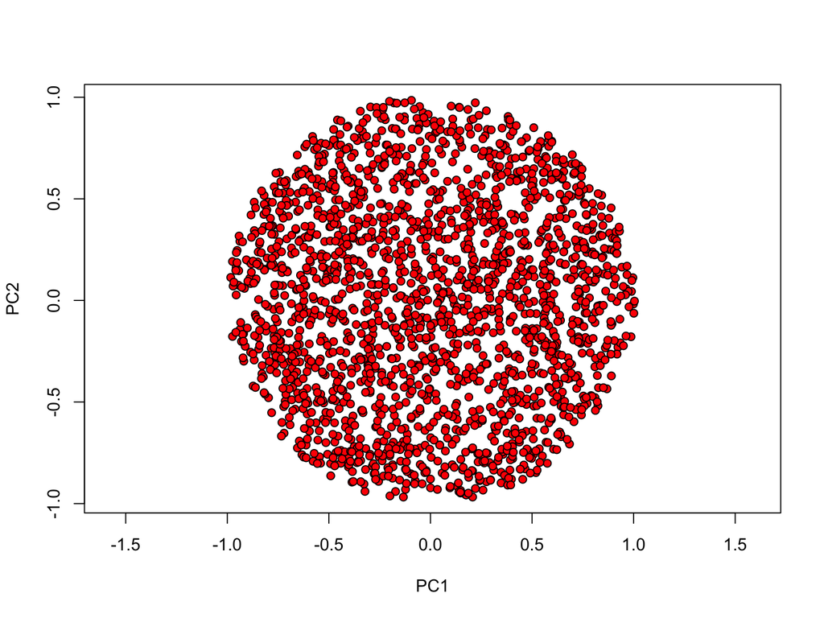

Same set of 2,000 randomly generated triangles.

# Shape Differences as Deformations

- With Tangent Space we can view patterns of shape variation; what about visualzing individual shape differences?
- D’Arcy Thompson, in “On Growth and Form” (1917) visualized shape differences using transformation grids
- Simple mathematical models to represent complex morphological changes

[figure not shown]

- Today we use the *Thin-Plate Spline* to generate such visualizations

# Shape Deformations: the Thin-Plate Spline

- Based on D’Arcy Thompson’s, Bookstein (1989) proposed using the thin-plate spline for providing a mathematically accurate representation of shape change (math was borrowed from engineering methods from 1980s)
- Deformation of a *reference* to a *target* specimen
- The coefficients of the fitted TPS model describe shape changes

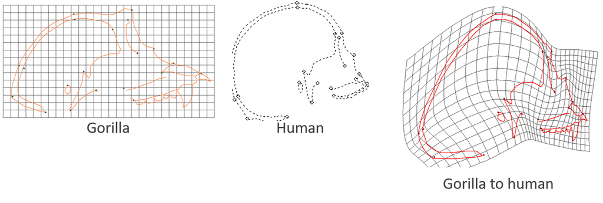

- The TPS is an alternative way of projecting aligned shape coordinates to tangent space (different math, but same result)

# The Thin-Plate Spline

- TPS is a smooth interpolation function (i.e., a doubly-differentiated equation)
- It models the differences in landmark locations between the reference and target specimen for each coordinate dimension separately (x,y)

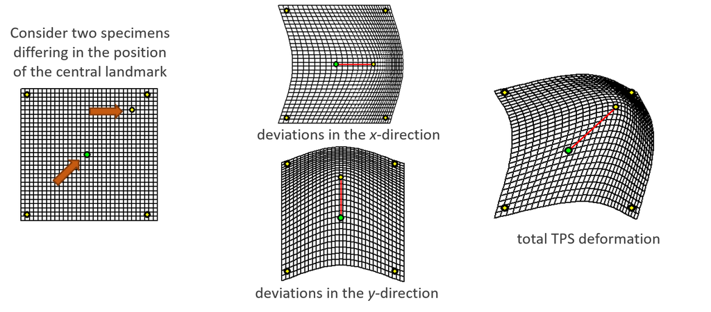

- This model provides $\small{2p-4}$ shape variables for 2D data and $\small{3p-7}$ for 3D data
- These are known as the *partial warp scores* and the *uniform component* (details ommited, but these are different types of potential shape transformations)

# Which Shape Variables to Use?

- We then have 3 shape variable options:
  - GPA-aligned coordinates
  - Kendall’s Tangent Space coordinates (GPA + orthogonal projection)
  - TPS variables (partial warp scores + uniform shape)
- Which ones should we use?

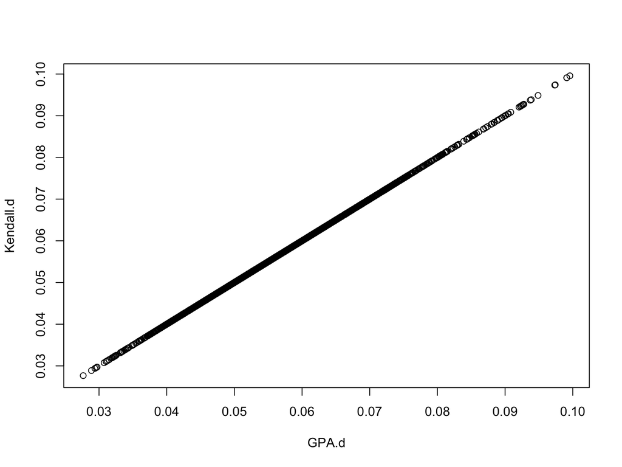

- **AND** correlation between PWS+U vs. Tangent space is **ALWAYS** 1.0 (see Rohlf 1999)

# Shape Variables: Conclusions

- Kendall’s Tangent coordinates & TPS shape variables yield identical results
  - They are simply rotations of one another
- GPA-aligned coordinates (unprojected) are close, but not exact
  - Difference due to curvature of shape space
- **Use Kendall´s Tangent Space Coordinates** to represent shape
- These are found from GPA + Orthogonal Projection
- NOTE: Most current papers use tangent space coordinates, aka Procrustes residuals combined with resampling tests (to accomodate singular dimensions)
- TPS then, is frequently used to **visualize shape differences**

# Exploring Shape Variation

- GM data are points in high-dimensional shape space
  - (e.g. for $\small{p=20}$ & $\small{k=3}$, shape space comprises 53 dimensions)
- Our human brains are limited to perception in up to 3 dimensions
- We need tools for visualizing and exploring shape variation in high-dimensional data spaces
- Principal Components Analysis (PCA) is one such tool

# Principal Components Analysis (PCA)

- PCA combines orthogonal rotation and projection to arrive at a summary plot of the data space
- The objective: to summarize most of the variation in as few dimensions as possible
- It consists of a rigid rotation of the data based on directions of variation, followed by projection to those new summary axes
- First one finds the set of axes the describe progressively less variation in the data
- Next, the data are rotated so that the main axis of variation (PC1) is horizontal
- Subsequent axes are orthogonal to PC1

# PCA: Conceptual Visualization

- This is what PCA does:

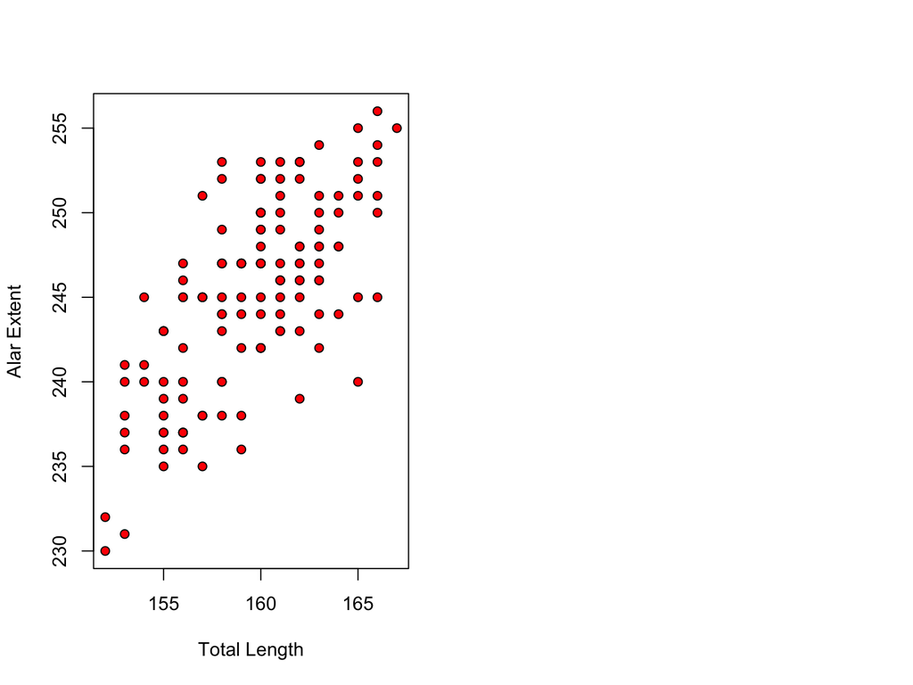

# PCA: Conceptual Visualization

- This is what PCA does:

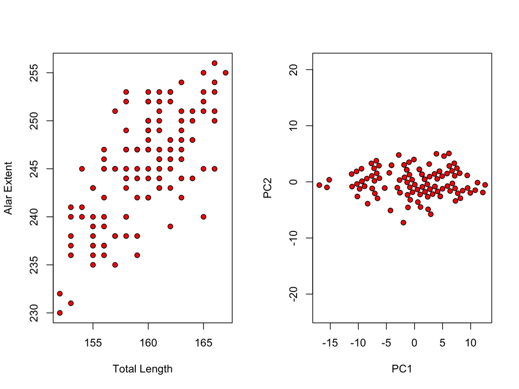

- PCA has performed a rigid rotation of the original data, so that variation is aligned with the new (PC) axes

# Visualizing Shape Differences

- TPS allows us to visualize what exactly changes in shape
- As an interpolation function, TPS allows us to precisely map all points of one shape to those of another shape, and visualize how they differ
- One may wish to visualize:
  - Differences between groups
  - Extremes of PC axes
  - How shape changes with size (allometry)
  - Shape evolution (differences between ancestor and descendent on a phylogeny)
- One can also magnify shape differences to aid biological interpretation

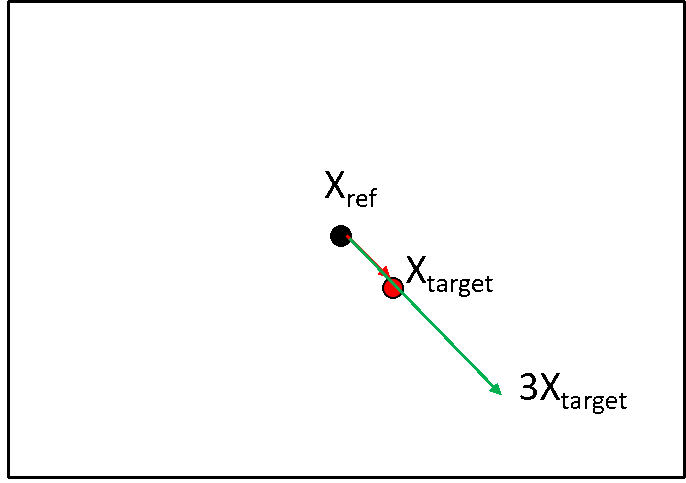

###### *TPS of Ref->Target is a vector in shape space, which can be extended in length

# Visualizing Shape Differences: Example

**TPS of male vs. female *Podarcis* (5X magnification)**

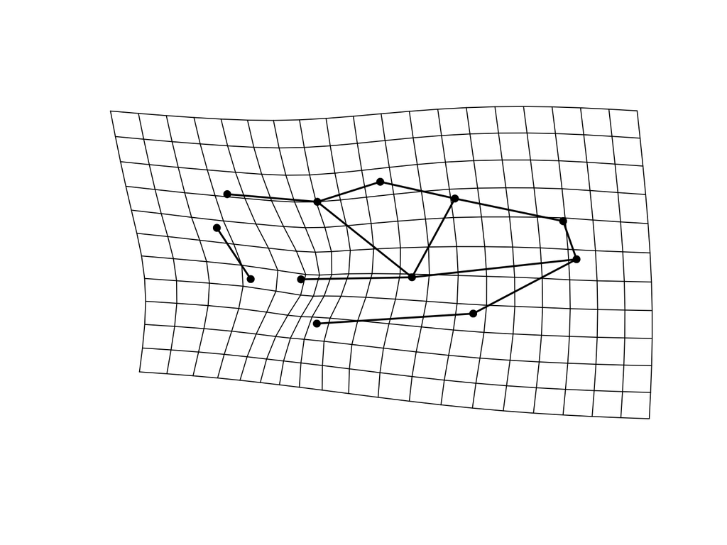

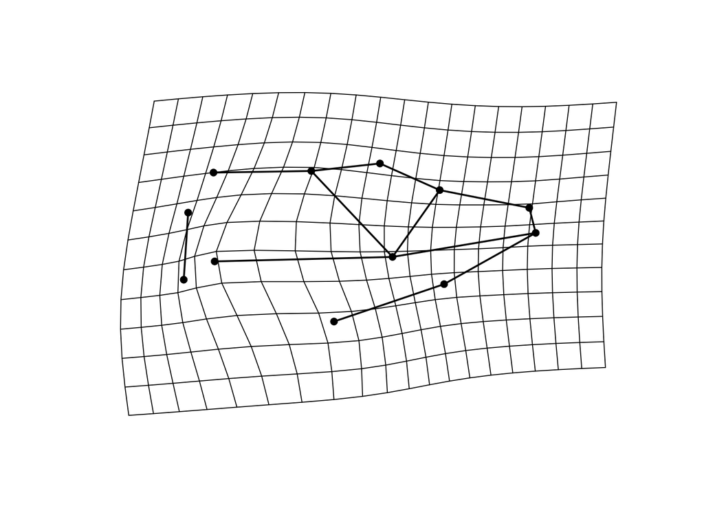

- Major difference in posterior region of skull

# Shape Variables: Conclusions

- Produce shape variables through projection to tangent space:
  - **Kendall´s tangent space coordinates (Procrustes residuals [GPA+Projection])**
- Explore shape variation through ordination in tangent space:
  - **PCA of shape data (aka Relative Warps)**
- Visualize shape variation to make biological interpretations:
  - **Use TPS to produce deformation grids**